# Nanofish: GST activity

# Set up environment

## Load libraries

## Load functions

## Load data

### Adjust classes and transformations

```
'data.frame':   467 obs. of  30 variables:
 $ StudyID             : Factor w/ 59 levels "2","3","4","5",..: 40 40 50 50 50 50 16 16 16 7 ...
 $ StudyCluster        : Factor w/ 34 levels "1","2","3","5",..: 4 4 5 5 5 5 4 4 4 18 ...
 $ Study               : Factor w/ 59 levels "Ašmonaitė et al., 2020",..: 1 1 2 2 2 2 3 3 3 4 ...
 $ Year                : int  2020 2020 2018 2018 2018 2018 2020 2020 2020 2019 ...
 $ EScluster           : Factor w/ 101 levels "1","2","3","4",..: 1 1 2 2 2 2 3 3 3 4 ...
 $ AdministrationRoute : Factor w/ 6 levels "Food","Injection",..: 1 1 4 4 4 4 1 1 1 4 ...
 $ Concentration_mg_L  : num  NA NA 0.26 0.69 0.26 0.69 NA NA NA 20 ...
 $ ParticleMaterial    : Factor w/ 7 levels "Aminoplast","LDPE",..: 6 3 1 1 1 1 3 3 3 6 ...
 $ Species             : Factor w/ 20 levels "Argyrosomus regius",..: 9 9 8 8 8 8 9 9 9 7 ...
 $ ParticleShape       : Factor w/ 4 levels "Irregular","Sphere",..: 2 2 2 2 2 2 2 2 2 2 ...
 $ Sex                 : Factor w/ 5 levels "F","F:M","FM",..: 5 5 5 5 5 5 5 5 5 NA ...
 $ DevelopmentalStage  : Factor w/ 5 levels "Embrio","Larva",..: 4 4 4 4 4 4 4 4 4 2 ...
 $ ExposureDurationCat : Factor w/ 3 levels "15 days +","5-15 days",..: 2 2 3 3 3 3 1 1 1 3 ...
 $ ExposureDurationDays: int  14 14 4 4 4 4 28 28 28 2 ...
```

[output cut: 16 more lines]

### Calculate Effect Size

```r
df_original <- metafor::escalc(measure = "SMD", n1i = n_treat, n2i = n_ctrl, m1i = mean_treat,
    m2i = mean_ctrl, sd1i = STD_treat, sd2i = STD_ctrl, data = df_original, vtype = "UB")
# write.csv(df_original,file = 'mvMetaAnalysis_SMDs.csv')
```

### Create variables

```r
outcome <- as.character(outcomeslist[[n_outcome]])

mRF <- list()  # random effects formula investigation models
mRE <- list()  # random effects multilevel models
mMR <- list()  # multilevel metaregression models

colormap <- c(Embrio = "khaki", Larva = "lightgreen", Juvenile = "lightskyblue",
    Adult = "salmon", Unclear = "plum", ExposureDurationDays = "cornflowerblue",
    ParticleSizeMean = "chartreuse4", Concentration_mg_L = "#fa0079ff", Aminoplast = "chocolate4",
    LDPE = "#2200faff", PE = "#0089faff", PET = "#00faedff", PLA = "#00fa29ff", PS = "#faf200ff",
    PVC = "#fa9a00ff", `Publication year` = "black", Variance = "navyblue")
```

### Select outcome

```
[1] "GST activity"
```

|  | StudyID | StudyCluster | Study | Year | EScluster | AdministrationRoute | Concentration_mg_L | ParticleMaterial | Species | ParticleShape | Sex | DevelopmentalStage | ExposureDurationCat | ExposureDurationDays | ParticleSizeRange | ParticleSizeMean | ParticleSizeCat | Outcome | OutcomeCategory | Test_or_Assay | OutcomeVariable | Group | n_of_groups | n_ctrl | mean_ctrl | STD_ctrl | n_treat | mean_treat | STD_treat | … |
| --- | --- | --- | --- | --- | --- | --- | --- | --- | --- | --- | --- | --- | --- | --- | --- | --- | --- | --- | --- | --- | --- | --- | --- | --- | --- | --- | --- | --- | --- | --- |
| 20 | 53 | 10 | Campos et al., 2021 | 2021 | 5 | Water: Static system | 0.1 | LDPE | Argyrosomus regius | Irregular |  | Larva | up to 96h | 1 | 63-125 | 94 | micro | GST activity | Neurochemical outcomes | Oxidative Stress | GST activity | 0.1 (black circle) | 3 | 5 | 8.189 | 1.612 | 5 | 8.034 | 0.653 | … |
| 21 | 53 | 10 | Campos et al., 2021 | 2021 | 5 | Water: Static system | 1 | LDPE | Argyrosomus regius | Irregular |  | Larva | up to 96h | 1 | 63-125 | 94 | micro | GST activity | Neurochemical outcomes | Oxidative Stress | GST activity | 1 (black circle) | 3 | 5 | 8.189 | 1.612 | 5 | 7.039 | 1.113 | … |
| 22 | 53 | 10 | Campos et al., 2021 | 2021 | 5 | Water: Static system | 10 | LDPE | Argyrosomus regius | Irregular |  | Larva | up to 96h | 1 | 63-125 | 94 | micro | GST activity | Neurochemical outcomes | Oxidative Stress | GST activity | 10 (black circle) | 3 | 5 | 8.189 | 1.612 | 5 | 5.734 | 0.768 | … |
| 187 | 107 | 27 | Parenti et al., 2021 | 2021 | 60 | Water: Semi-static system | 0.2 | PS | Danio rerio | Unclear |  | Larva | 5-15 days | 7 | 0.5 | 0.5 | nano | GST activity | Neurochemical outcomes | Oxidative Stress | GST activity | PNP | 1 | 3 | 319.283 | 59.317 | 3 | 320.864 | 28.29 | … |
| 220 | 116 | 13 | Rios-Fuster et al., 2021 | 2021 | 69 | Food |  | LDPE | Sparus aurata | Irregular |  | Juvenile | 15 days + | 21 | 100-500 | 300 | micro | GST activity | Neurochemical outcomes | Oxidative Stress | GST activity | Virgin | 1 | 12 | 585.6709939 | 246.2654818 | 12 | 671.7125166 | 91.65356496 | … |
| 233 | 93 | 26 | Romano et al., 2020 | 2020 | 72 | Water: Semi-static system | 0.1 | PVC | Carassius auratus | Irregular |  | Juvenile | up to 96h | 4 | 0.1-1000 |  | mix | GST activity | Neurochemical outcomes | Oxidative Stress | GST activity | 0.1 mg/L | 2 | 3 | 129.608 | 20.653 | 3 | 128.571 | 17.959 | … |
| 234 | 93 | 26 | Romano et al., 2020 | 2020 | 72 | Water: Semi-static system | 0.5 | PVC | Carassius auratus | Irregular |  | Juvenile | up to 96h | 4 | 0.1-1000 |  | mix | GST activity | Neurochemical outcomes | Oxidative Stress | GST activity | 0.5 mg/L | 2 | 3 | 129.608 | 20.653 | 3 | 178.859 | 30.53 | … |
| 240 | 62 | 25 | Santos et al., 2020 | 2020 | 73 | Water: Semi-static system | 2 | Aminoplast | Danio rerio | Sphere |  | Larva | up to 96h | 4 | 1-5 | 3 | micro | GST activity | Neurochemical outcomes | Oxidative Stress | GST activity | MP | 1 | 5 | 0.05 | 0.01 | 5 | 0.06 | 0.01 | … |
| 264 | 112 | 25 | Santos et al., 2021b | 2021 | 75 | Water: Semi-static system | 2 | Aminoplast | Danio rerio | Sphere |  | Larva | up to 96h | 2 | 1-5 | 3 | micro | GST activity | Neurochemical outcomes | Oxidative Stress | GST activity | MPs 2 | 1 | 3 | 72.4 | 10.7 | 3 | 69.2 | 17.1 | … |
| 265 | 112 | 25 | Santos et al., 2021b | 2021 | 76 | Water: Semi-static system | 2 | Aminoplast | Danio rerio | Sphere |  | Larva | 5-15 days | 6 | 1-5 | 3 | micro | GST activity | Neurochemical outcomes | Oxidative Stress | GST activity | MPs 6 | 1 | 3 | 158.9 | 14.8 | 3 | 174.4 | 27.3 | … |

[output cut: 12 more lines]

# Exploratory data analysis

## Funnel plot

> Before running any meta-analytic model, it is important to explore the meta-analytic dataset to search for potential outliers that could represent data extraction errors. (Nakagawa et al. 2022)

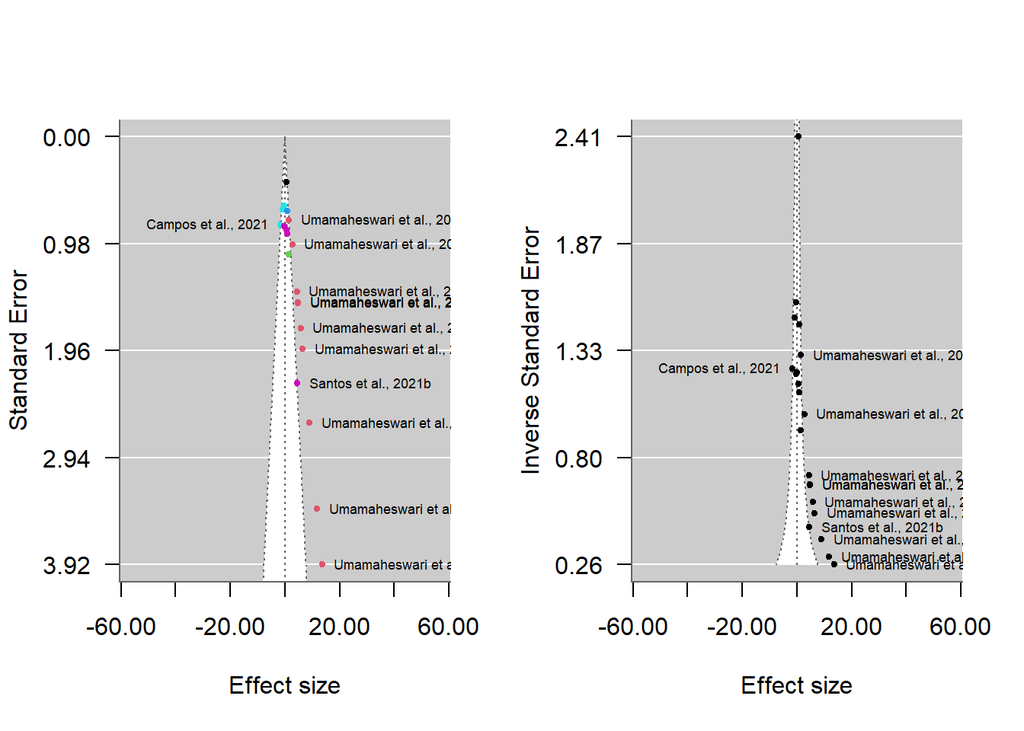

## Alluvial plot

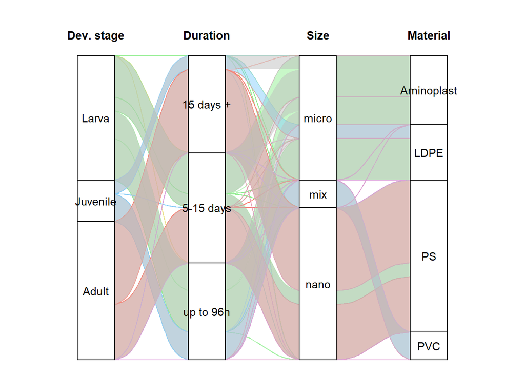

# Multilevel meta-analytic model

## Random effects formula desing

```
[1] "Considering number of studies: 7, number of ES clusters: 14 and number of independent observations of ES: 22, the random effects formula for GST activity is: ~1 | Study/EScluster/ESid"
```

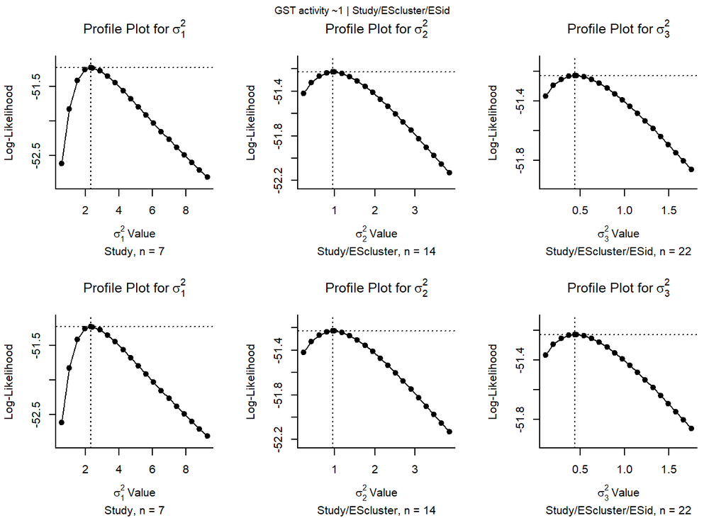

> A profile likelihood plot should show a single peak at the corresponding ML/REML estimate. If `refline=TRUE` (the default), the value of the parameter estimate is indicated by a dotted vertical line and its log-likelihood value by a dotted horizontal line. Hence, the intersection of these two lines should correspond to the peak (assuming that the model was fitted with ML/REML estimation).

> When profiling a variance component (or some other parameter that cannot be negative), the peak may be at zero (if this corresponds to the ML/REML estimate of the parameter). In this case, the profiled log-likelihood should be a monotonically decreasing function of the parameter. Similarly, when profiling a correlation component, the peak may be at -1 or +1.

> If the profiled log-likelihood has multiple peaks, this indicates that the likelihood surface is not unimodal. In such cases, the ML/REML estimate may correspond to a local optimum (when the intersection of the two dotted lines is not at the highest peak).

> If the profile is flat (over the entire parameter space or large portions of it), then this suggests that at least some of the parameters of the model are not identifiable (and the parameter estimates obtained are to some extent arbitrary). See Raue et al. (2009) for some further discussion of parameter identifiability and the use of profile likelihoods to check for this.

> The function checks whether any profiled log-likelihood value is actually larger than the log-likelihood of the fitted model (using a numerical tolerance of `lltol`). If so, a warning is issued as this might indicate that the optimizer did not identify the actual ML/REML estimate of the parameter profiled.[Viechtbauer (2022)](Viechtbauer 2010)

## Additional random effects factors

Study cluster, particle material and species as random effects term can further improve results?

|  | Nested | +StudyCluster | +Particle Material | +Species |
| --- | --- | --- | --- | --- |
| logLik: | -51.22792148110516 | -50.91311092130478 | -51.22792148699055 | -51.22792148616819 |
| deviance: | 55.33723977588708 | 54.70761865628634 | 55.33723978765787 | 55.33723978601314 |
| AIC: | 110.4558429622103 | 111.8262218426096 | 112.4558429739811 | 112.4558429723364 |
| BIC: | 114.8200127756436 | 117.2814341094011 | 117.9110552407727 | 117.9110552391279 |
| AICc: | 112.8087841386809 | 115.5762218426096 | 116.2058429739811 | 116.2058429723364 |

|  | Comparison | LRT | p_value |
| --- | --- | --- | --- |
| 1 | +Study Cluster | 0.63 | 0.427 |
| 2 | +Particle Material | 0 | 1 |
| 3 | +Species | 0 | 1 |

## Main result: Multilevel model with $\rho = 0.5$ and robust variance estimate

```r
# Assumed correlation of rho = 0.5, except if there is only one ES by Study (no
# correlation)
if (nES == nSt) {
    VCVrho <- 0
    VCV <- df$vi
} else {
    VCVrho <- 0.5
    VCV <- vcalc(vi, cluster = interaction(df$EScluster, df$Study), obs = ESid, data = df,
        rho = VCVrho)
}

mname1 <- "ML"
mname2 <- paste0(mname1, "_RobVar")

mRE[[mname1]] <- rma.mv(yi, VCV, random = RE_formula, data = df, slab = Study, method = "REML",
    test = "t", dfs = "contain", level = 95)
mRE[[mname1]] <- additional_results(mRE[[mname1]])

mRE[[mname2]] <- robust(mRE[[mname1]], cluster = df$Study, clubSandwich = TRUE)

mRE[[mname2]] <- additional_results(mRE[[mname2]])

I2_ML_RobVar <- i2_ml(mRE[[mname2]])
# I2_ML_RobVar <- i2_ml(mRE[[mname2]], boot = 1000)

extract_report(mRE[[mname2]], outcome, RE_formula)
```

#### Diagnostics plots and results

```
Multivariate Meta-Analysis Model (k = 22; method: REML)

  logLik  Deviance       AIC       BIC      AICc
-47.9993   95.9986  103.9986  108.1767  106.4986

Variance Components:

            estim    sqrt  nlvls  fixed                factor
sigma^2.1  2.0033  1.4154      7     no                 Study
sigma^2.2  0.0000  0.0001     14     no       Study/EScluster
sigma^2.3  0.7814  0.8840     22     no  Study/EScluster/ESid

Test for Heterogeneity:
Q(df = 21) = 71.6607, p-val < .0001

Number of estimates:   22
Number of clusters:    7
Estimates per cluster: 0-10 (mean: 0.37, median: 0)

Model Results:

estimate      se¹    tval¹    df¹    pval¹    ci.lb¹   ci.ub¹
  0.9043  0.6679   1.3540   5.89   0.2254   -0.7374   2.5460

---
Signif. codes:  0 '***' 0.001 '**' 0.01 '*' 0.05 '.' 0.1 ' ' 1

1) results based on cluster-robust inference (var-cov estimator: CR2,
   approx t-test and confidence interval, df: Satterthwaite approx)
```

```
[1] 0.719 0.000 0.281
```

```
               I2_Total                I2_Study      I2_Study/EScluster
           7.680257e+01            5.525061e+01            3.485903e-07
I2_Study/EScluster/ESid
           2.155196e+01
```

```
$results
        % of total variance    I2
Level 1        2.319743e+01   ---
Level 2        2.155196e+01 21.55
Level 3        3.485903e-07     0
Level 4        5.525061e+01 55.25

$totalI2
[1] 76.80257

$plot
```

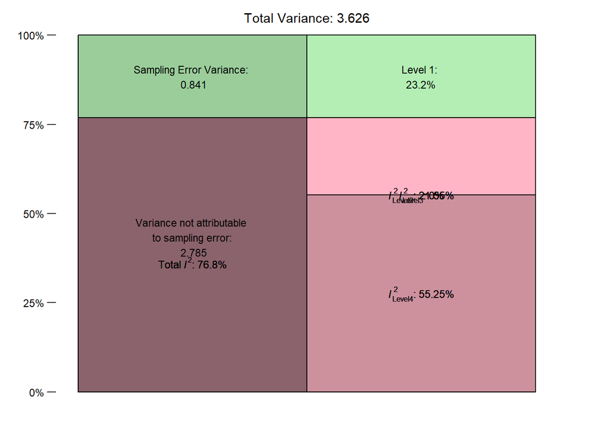

```
attr(,"class")
[1] "mlm.variance.distribution" "list"
```

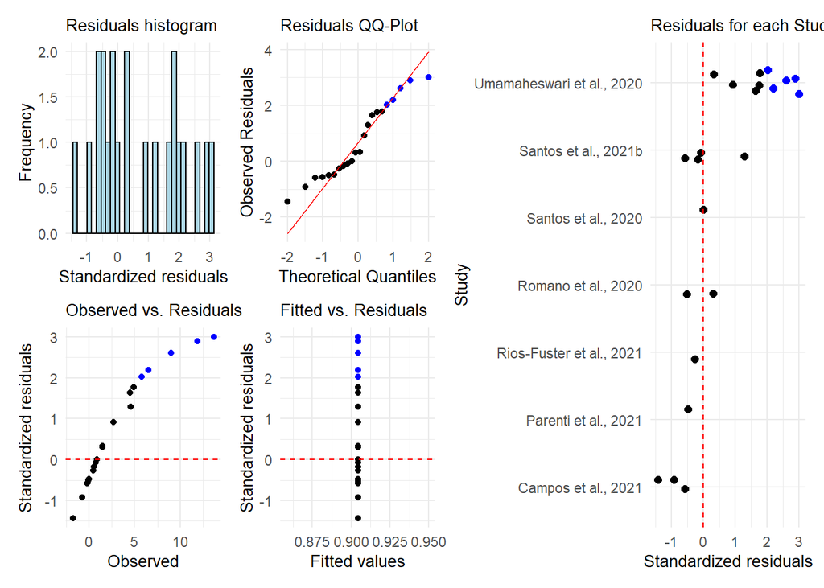

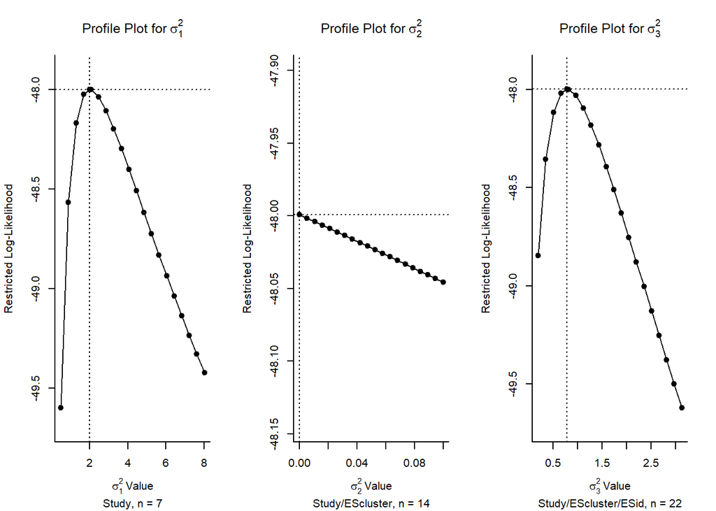

### Forest plot

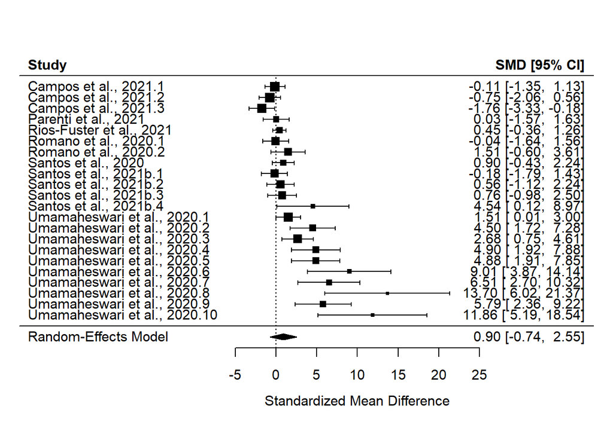

The meta-analysis comprised 22 comparisons from 14 control group clusters of 7 independent studies, so the random formula for GST activity was ~1 | Study/EScluster/ESid.

No difference between treatment and control groups (ES = 0.9043169 ± 0.6678848, CI95% = -0.7373665 to 2.5460003, predicted interval -3.5138263 to 5.32246), with high heterogeneity (i² = 76.8, Q = 71.6607417, p < 0.001 ) and variance explained by each component of $\sigma^2_{Study} = 2.00$, $\sigma^2_{EScluster} = 0.00$, $\sigma^2_{ESid} = 0.78$.

# Publication bias

> **Small-study effect:** when small studies (with small sample sizes) tend to report large effect sizes. (Yang et al. 2023)

> While the PET method works best when the true effect captured by β0β0 is **zero**, PEESE shows a better performance when the true effect is **not** zero. Stanley and Doucouliagos ([2014](https://bookdown.org/MathiasHarrer/Doing_Meta_Analysis_in_R/references.html#ref-stanley2014meta)) therefore proposed to combine both methods, in order to balance out their individual strengths. The resulting approach is the PET-PEESE method. PET-PEESE uses the intercept β0 of either PET or PEESE as the estimate of the corrected true effect.

> Whether PET or PEESE is used depends on the size of the intercept calculated by the PET method. When β0PET is significantly larger than zero in a one-sided test with α = 0.05, we use the intercept of PEESE as the true effect size estimate. If PET’s intercept is not significantly larger than zero, we remain with the PET estimate.

> In most implementations of regression models in *R*, it is conventional to test the significance of coefficients using a two-sided test (i.e. we test if a ββ weight significantly differs from zero, no matter the direction). To assume a one-sided test with α = 0.05, we already regard the intercept as significant when p < 0.1, and when the estimate of β0 is larger than zero<sup>38</sup>. (Harrer et al., n.d.)

> **Time-lag bias:** when statistically significant (“positive” results) tend to be published earlier than those with statistically non-significant findings (“negative” results), leading to a decline in reported effect sizes over time (i.e., a decline effect). (Yang et al. 2023)

> Given that high heterogeneity may invalidate publication bias test, it is best to account for the potential heterogeneity when testing publication bias. (Yang et al. 2023)

> PET-PEESE performs poorly in research areas where there are only a few studies, all studies use small samples, and where there is very high heterogeneity of results from study to study. Nonetheless, the statistical properties of conventional meta-analysis approaches are much worse than PET-PEESE under these same conditions.(Stanley 2017)

So, **better use meta-regression dataset**, but requires larger dataset to avoid possible convergence issues.

#### Plots

```
[1] "PET"
```

```
Multivariate Meta-Analysis Model (k = 22; method: REML)

  logLik  Deviance       AIC       BIC      AICc
-28.5952   57.1904   69.1904   74.8570   76.1904

Variance Components:

            estim    sqrt  nlvls  fixed                factor
sigma^2.1  0.5507  0.7421      7     no                 Study
sigma^2.2  0.0000  0.0001     14     no       Study/EScluster
sigma^2.3  0.1951  0.4417     22     no  Study/EScluster/ESid

Test for Residual Heterogeneity:
QE(df = 19) = 26.0361, p-val = 0.1292

Number of estimates:   22
Number of clusters:    7
Estimates per cluster: 0-10 (mean: 0.37, median: 0)

Test of Moderators (coefficients 2:3):¹
F(df1 = 2, df2 = 1.51) = 4.8037, p-val = 0.2210

Model Results:

          estimate         se¹     tval¹    df¹    pval¹       ci.lb¹
intrcpt  1668.5992  1393.5922    1.1973   4.21   0.2943   -2126.8651
ESSE        3.5495     0.8887    3.9941   1.39   0.1009      -2.4510
Year       -0.8268     0.6898   -1.1986   4.21   0.2938      -2.7054
             ci.ub¹
intrcpt  5464.0634
ESSE        9.5500
Year        1.0517

---
Signif. codes:  0 '***' 0.001 '**' 0.01 '*' 0.05 '.' 0.1 ' ' 1

1) results based on cluster-robust inference (var-cov estimator: CR2,
   approx t/F-tests and confidence intervals, df: Satterthwaite approx)
```

```
  pred   se ci.lb ci.ub pi.lb pi.ub
 -1.90 0.66 -4.13  0.32 -5.57  1.77
```

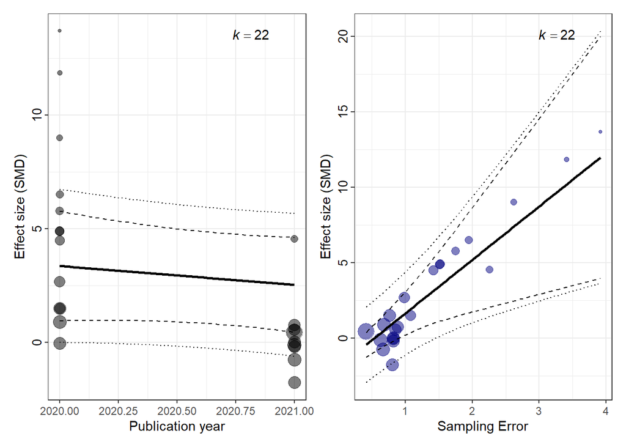

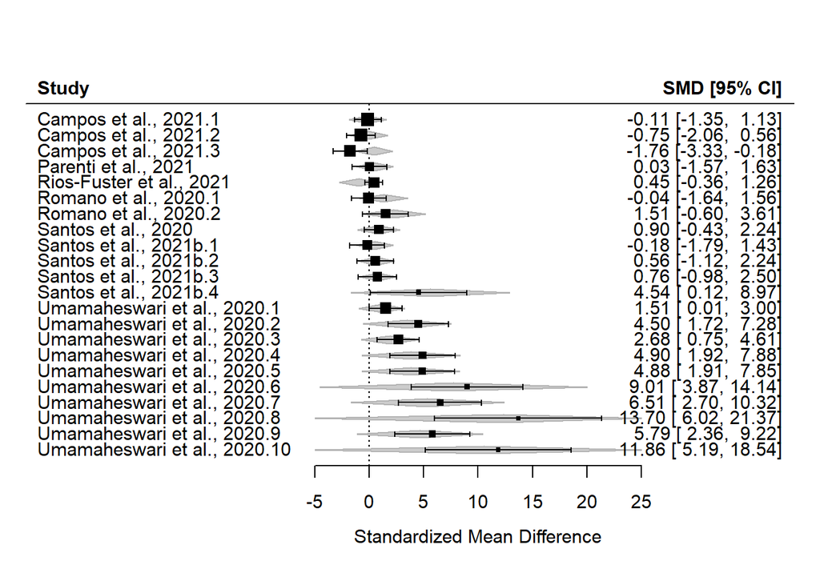

**Small-study effect** The regression slope of the extended Egger’s regression is $\sqrt{SMDSE} = 3.5494578$ is it statistically different from zero?`

If p<0.050: Smaller studies (with larger sampling error) have larger effect sizes –> small-study effect exists in this dataset. Data is assymmetrically distributed in the funnel plot.

If p>=0.050 no small-study effect exists in this dataset. Smaller studies (with larger sampling error) do not have larger effect sizes –> no small-study effect exists in this dataset. Data is symmetrically distributed in the funnel plot.

If p<0.050: studies with statistically significant findings tend to be published earlier than these with “negative” results, i.e. time-lag bias exists in this dataset

If p>=0.050: studies with statistically significant findings **do not** tend to be published earlier than these with “negative” results, i.e. no time-lag bias exists in this dataset

### Sensitivity analysis: publication bias with adapted SE

> Egger’s regression and its variants suffer from low power and poor performance when there are fewer than 20 effect sizes, or when the overall effect is large. (Nakagawa et al. 2022)

> Instead of the sample size (n1 + n2), however, for a meta-analysis of SMD or lnRR, we propose using the ‘effective sample size’ because it accounts for unbalanced sampling (cf. Stanley, 2005).(Nakagawa et al. 2022)

```r
if (mRE[[bias]]$pval[2] < 0.05) {

    # calculate modified SE based on effective sample size
    df$ess_vi <- with(df, sqrt((n_treat + n_ctrl)/(n_treat * n_ctrl)))
    df$ess_SE <- sqrt(df$ess_vi)  ## sampling error for ES

    # PET + year
    bias2 <- "PET sensitivity"
    mRE[[bias2]] <- rma.mv(yi, VCV, random = RE_formula, mods = ~ess_SE + Year, data = df,
        slab = Study, method = "REML", test = "t", dfs = "contain", level = 95)
    mRE[[bias2]] <- robust(mRE[[bias2]], cluster = df$Study, clubSandwich = TRUE)
    mRE[[bias2]] <- additional_results(mRE[[bias2]])
    mRE[[bias2]][["pi"]] <- predict(mRE[[bias2]], newmods = c(0, mean(df$Year)),
        digits = 2)

    # PEESE + year
    if (mRE[[bias2]]$pval[2] < 0.1) {
        mname <- "PEESE sensitivity"
        mRE[[mname]] <- rma.mv(yi, VCV, random = RE_formula, mods = ~ess_vi + Year,
            data = df, slab = Study, method = "REML", test = "t", dfs = "contain",
            level = 95)
        mRE[[mname]] <- robust(mRE[[mname]], cluster = df$Study, clubSandwich = TRUE)
        mRE[[mname]] <- additional_results(mRE[[mname]])
        mRE[[mname]][["pi"]] <- predict(mRE[[mname]], newmods = c(0, mean(df$Year)),
            digits = 2)
        bias2 <- mname
    }
}
```

If the results are the same, indicates the robustness of the small-study test.

#### Plots

# Sensitivity

## Rho range

```r
if (VCVrho != 0) {

    rho_range <- c(0, 0.25, 0.75, 0.9)  # assume a range values of rho

    for (j in 1:length(rho_range)) {

        mname <- paste("rho", rho_range[j], sep = "_")

        VCV2 <- vcalc(vi, cluster = interaction(df$EScluster, df$Study), obs = ESid,
            data = df, rho = rho_range[j])

        mRE[[mname]] <- rma.mv(yi, VCV2, random = RE_formula, data = df, slab = Study,
            method = "REML", test = "t", dfs = "contain", level = 95)
        mRE[[mname]] <- robust(mRE[[mname]], cluster = df$Study, clubSandwich = TRUE)
        mRE[[mname]] <- additional_results(mRE[[mname]])
    }
}
```

## Leave one out + Rho range

```r
if (VCVrho != 0) {
    rho_range <- c(0.25, 0.5, 0.75, 0.9)
} else {
    rho_range <- 0
}

for (i in sort(unique(df$Study))) {

    df_temp <- df[df$Study != i, ]

    for (j in 1:length(rho_range)) {

        mname <- paste("rho", rho_range[j], "l1o", i, sep = "_")
        print(mname)
        VCV2 <- vcalc(vi, cluster = interaction(df_temp$EScluster, df_temp$Study),
            obs = ESid, data = df_temp, rho = rho_range[j])

        mRE[[mname]] <- rma.mv(yi, VCV2, random = RE_formula, data = df_temp, slab = Study,
            method = "REML", test = "t", dfs = "contain", level = 95)
        mRE[[mname]] <- robust(mRE[[mname]], cluster = df_temp$Study, clubSandwich = TRUE)
        mRE[[mname]] <- additional_results(mRE[[mname]])
    }
}
```

```
[1] "rho_0.25_l1o_Campos et al., 2021"
[1] "rho_0.5_l1o_Campos et al., 2021"
[1] "rho_0.75_l1o_Campos et al., 2021"
[1] "rho_0.9_l1o_Campos et al., 2021"
[1] "rho_0.25_l1o_Parenti et al., 2021"
[1] "rho_0.5_l1o_Parenti et al., 2021"
[1] "rho_0.75_l1o_Parenti et al., 2021"
[1] "rho_0.9_l1o_Parenti et al., 2021"
[1] "rho_0.25_l1o_Rios-Fuster et al., 2021"
[1] "rho_0.5_l1o_Rios-Fuster et al., 2021"
[1] "rho_0.75_l1o_Rios-Fuster et al., 2021"
[1] "rho_0.9_l1o_Rios-Fuster et al., 2021"
[1] "rho_0.25_l1o_Romano et al., 2020"
[1] "rho_0.5_l1o_Romano et al., 2020"
[1] "rho_0.75_l1o_Romano et al., 2020"
[1] "rho_0.9_l1o_Romano et al., 2020"
[1] "rho_0.25_l1o_Santos et al., 2020"
[1] "rho_0.5_l1o_Santos et al., 2020"
[1] "rho_0.75_l1o_Santos et al., 2020"
[1] "rho_0.9_l1o_Santos et al., 2020"
[1] "rho_0.25_l1o_Santos et al., 2021b"
[1] "rho_0.5_l1o_Santos et al., 2021b"
[1] "rho_0.75_l1o_Santos et al., 2021b"
[1] "rho_0.9_l1o_Santos et al., 2021b"
[1] "rho_0.25_l1o_Umamaheswari et al., 2020"
[1] "rho_0.5_l1o_Umamaheswari et al., 2020"
[1] "rho_0.75_l1o_Umamaheswari et al., 2020"
[1] "rho_0.9_l1o_Umamaheswari et al., 2020"
```

# Tables

|  | n studies | n ES clusters | n ES | overall effect | standard error | p-value | Lower CI | Upper CI | Lower PI | Upper PI | Q | Q p-value | $I^2$$_{total}$ | $I^2$$_{Study}$ | $I^2$$_{EScluster}$ | $I^2$$_{ES}$ | $\sigma^2$$_{Study}$ | $\sigma^2$$_{EScluster}$ | $\sigma^2$$_{ES}$ |
| --- | --- | --- | --- | --- | --- | --- | --- | --- | --- | --- | --- | --- | --- | --- | --- | --- | --- | --- | --- |
| ML | 7 | 14 | 22 | 0.90 | 0.6 | 0.2052 | -0.65 | 2.46 | -3.47 | 5.27 | 71.66 | 0.00 | 76.80 | 55.25 | 0.00 | 21.55 | 2.00 | 0.00 | 0.78 |
| ML_RobVar | 7 | 14 | 22 | 0.90 | 0.7 | 0.2254 | -0.74 | 2.55 | -3.51 | 5.32 | 71.66 | 0.00 | 76.80 | 55.25 | 0.00 | 21.55 | 2.00 | 0.00 | 0.78 |
| PET | 7 | 14 | 22 | 1668.60 | 1393.6 | 0.2943 | -2126.87 | 5464.06 | -5.57 | 1.77 | 26.04 | 0.13 | 47.00 | 34.70 | 0.00 | 12.29 | 0.55 | 0.00 | 0.20 |
| rho_0 | 7 | 14 | 22 | 1.12 | 0.8 | 0.2193 | -0.89 | 3.13 | -4.45 | 6.69 | 98.78 | 0.00 | 84.11 | 53.39 | 21.67 | 9.04 | 2.83 | 1.15 | 0.48 |
| rho_0.25 | 7 | 14 | 22 | 0.97 | 0.7 | 0.2252 | -0.79 | 2.74 | -3.83 | 5.78 | 80.67 | 0.00 | 79.71 | 56.85 | 6.13 | 16.73 | 2.36 | 0.25 | 0.69 |
| rho_0.75 | 7 | 14 | 22 | 0.89 | 0.7 | 0.2215 | -0.71 | 2.49 | -3.42 | 5.20 | 72.73 | 0.00 | 75.85 | 48.76 | 0.00 | 27.10 | 1.70 | 0.00 | 0.94 |
| rho_0.9 | 7 | 14 | 22 | 0.89 | 0.6 | 0.2204 | -0.71 | 2.50 | -3.46 | 5.25 | 96.22 | 0.00 | 76.16 | 42.82 | 0.00 | 33.34 | 1.51 | 0.00 | 1.18 |
| rho_0.25_l1o_Campos et al., 2021 | 6 | 13 | 19 | 1.37 | 0.8 | 0.1532 | -0.73 | 3.46 | -3.98 | 6.71 | 65.77 | 0.00 | 78.75 | 51.15 | 2.57 | 25.03 | 2.33 | 0.12 | 1.14 |
| rho_0.5_l1o_Campos et al., 2021 | 6 | 13 | 19 | 1.30 | 0.8 | 0.1474 | -0.66 | 3.27 | -3.64 | 6.24 | 59.84 | 0.00 | 75.91 | 48.48 | 0.00 | 27.44 | 1.95 | 0.00 | 1.10 |
| rho_0.75_l1o_Campos et al., 2021 | 6 | 13 | 19 | 1.29 | 0.7 | 0.1431 | -0.63 | 3.21 | -3.54 | 6.12 | 60.54 | 0.00 | 74.88 | 42.19 | 0.00 | 32.69 | 1.63 | 0.00 | 1.26 |
| rho_0.9_l1o_Campos et al., 2021 | 6 | 13 | 19 | 1.32 | 0.7 | 0.1416 | -0.64 | 3.27 | -3.64 | 6.27 | 75.52 | 0.00 | 75.69 | 36.51 | 0.00 | 39.18 | 1.45 | 0.00 | 1.56 |
| rho_0.25_l1o_Parenti et al., 2021 | 6 | 13 | 21 | 1.14 | 0.8 | 0.2304 | -1.01 | 3.29 | -4.44 | 6.72 | 79.69 | 0.00 | 82.30 | 57.21 | 9.42 | 15.67 | 2.76 | 0.45 | 0.76 |
| rho_0.5_l1o_Parenti et al., 2021 | 6 | 13 | 21 | 1.03 | 0.8 | 0.2341 | -0.94 | 3.01 | -4.01 | 6.08 | 70.76 | 0.00 | 79.11 | 57.39 | 0.00 | 21.73 | 2.35 | 0.00 | 0.89 |
| rho_0.75_l1o_Parenti et al., 2021 | 6 | 13 | 21 | 1.02 | 0.7 | 0.2307 | -0.90 | 2.94 | -3.90 | 5.94 | 72.03 | 0.00 | 78.22 | 51.25 | 0.00 | 26.98 | 2.01 | 0.00 | 1.06 |
| rho_0.9_l1o_Parenti et al., 2021 | 6 | 13 | 21 | 1.02 | 0.7 | 0.2298 | -0.91 | 2.95 | -3.97 | 6.01 | 95.87 | 0.00 | 78.63 | 45.55 | 0.00 | 33.08 | 1.82 | 0.00 | 1.32 |
| rho_0.25_l1o_Rios-Fuster et al., 2021 | 6 | 13 | 21 | 1.10 | 0.9 | 0.2597 | -1.13 | 3.32 | -4.63 | 6.82 | 79.65 | 0.00 | 80.64 | 56.43 | 9.26 | 14.94 | 2.91 | 0.48 | 0.77 |
| rho_0.5_l1o_Rios-Fuster et al., 2021 | 6 | 13 | 21 | 0.99 | 0.8 | 0.2668 | -1.05 | 3.03 | -4.19 | 6.17 | 70.82 | 0.00 | 77.29 | 56.56 | 0.00 | 20.73 | 2.49 | 0.00 | 0.91 |
| rho_0.75_l1o_Rios-Fuster et al., 2021 | 6 | 13 | 21 | 0.97 | 0.8 | 0.2634 | -1.02 | 2.97 | -4.09 | 6.03 | 72.28 | 0.00 | 76.37 | 50.71 | 0.00 | 25.65 | 2.14 | 0.00 | 1.08 |
| rho_0.9_l1o_Rios-Fuster et al., 2021 | 6 | 13 | 21 | 0.98 | 0.8 | 0.2614 | -1.02 | 2.98 | -4.15 | 6.11 | 96.20 | 0.00 | 76.78 | 45.30 | 0.00 | 31.48 | 1.95 | 0.00 | 1.35 |
| rho_0.25_l1o_Romano et al., 2020 | 6 | 13 | 20 | 1.07 | 0.9 | 0.2713 | -1.16 | 3.31 | -4.68 | 6.82 | 78.68 | 0.00 | 83.24 | 58.42 | 9.38 | 15.44 | 2.94 | 0.47 | 0.78 |
| rho_0.5_l1o_Romano et al., 2020 | 6 | 13 | 20 | 0.96 | 0.8 | 0.2783 | -1.08 | 3.01 | -4.22 | 6.15 | 68.77 | 0.00 | 80.08 | 58.87 | 0.00 | 21.21 | 2.50 | 0.00 | 0.90 |
| rho_0.75_l1o_Romano et al., 2020 | 6 | 13 | 20 | 0.95 | 0.8 | 0.2740 | -1.04 | 2.93 | -4.10 | 5.99 | 67.18 | 0.00 | 79.13 | 52.89 | 0.00 | 26.23 | 2.14 | 0.00 | 1.06 |
| rho_0.9_l1o_Romano et al., 2020 | 6 | 13 | 20 | 0.95 | 0.8 | 0.2736 | -1.05 | 2.96 | -4.19 | 6.10 | 83.18 | 0.00 | 79.73 | 47.28 | 0.00 | 32.45 | 1.97 | 0.00 | 1.35 |
| rho_0.25_l1o_Santos et al., 2020 | 6 | 13 | 21 | 1.02 | 0.9 | 0.2885 | -1.19 | 3.23 | -4.69 | 6.73 | 80.65 | 0.00 | 82.55 | 58.31 | 8.97 | 15.27 | 2.93 | 0.45 | 0.77 |
| rho_0.5_l1o_Santos et al., 2020 | 6 | 13 | 21 | 0.92 | 0.8 | 0.2969 | -1.11 | 2.94 | -4.25 | 6.08 | 71.62 | 0.00 | 79.44 | 58.37 | 0.00 | 21.07 | 2.49 | 0.00 | 0.90 |
| rho_0.75_l1o_Santos et al., 2020 | 6 | 13 | 21 | 0.90 | 0.8 | 0.2932 | -1.08 | 2.88 | -4.14 | 5.94 | 72.61 | 0.00 | 78.56 | 52.43 | 0.00 | 26.13 | 2.15 | 0.00 | 1.07 |
| rho_0.9_l1o_Santos et al., 2020 | 6 | 13 | 21 | 0.91 | 0.8 | 0.2901 | -1.08 | 2.89 | -4.20 | 6.01 | 95.82 | 0.00 | 78.93 | 46.85 | 0.00 | 32.08 | 1.95 | 0.00 | 1.34 |
| rho_0.25_l1o_Santos et al., 2021b | 6 | 10 | 18 | 1.13 | 1.0 | 0.2946 | -1.37 | 3.63 | -5.21 | 7.47 | 76.33 | 0.00 | 85.92 | 55.41 | 15.89 | 14.63 | 3.27 | 0.94 | 0.86 |
| rho_0.5_l1o_Santos et al., 2021b | 6 | 10 | 18 | 0.98 | 0.8 | 0.3018 | -1.21 | 3.17 | -4.53 | 6.49 | 67.41 | 0.00 | 82.17 | 58.73 | 0.00 | 23.44 | 2.74 | 0.00 | 1.09 |
| rho_0.75_l1o_Santos et al., 2021b | 6 | 10 | 18 | 0.96 | 0.8 | 0.3045 | -1.20 | 3.12 | -4.45 | 6.36 | 68.65 | 0.00 | 81.49 | 53.55 | 0.00 | 27.94 | 2.41 | 0.00 | 1.26 |
| rho_0.9_l1o_Santos et al., 2021b | 6 | 10 | 18 | 0.96 | 0.8 | 0.3093 | -1.24 | 3.16 | -4.56 | 6.49 | 92.23 | 0.00 | 82.11 | 48.60 | 0.00 | 33.51 | 2.26 | 0.00 | 1.56 |
| rho_0.25_l1o_Umamaheswari et al., 2020 | 6 | 9 | 12 | 0.25 | 0.3 | 0.3844 | -0.45 | 0.95 | -0.76 | 1.26 | 14.49 | 0.21 | 11.19 | 11.19 | 0.00 | 0.00 | 0.07 | 0.00 | 0.00 |
| rho_0.5_l1o_Umamaheswari et al., 2020 | 6 | 9 | 12 | 0.29 | 0.2 | 0.2495 | -0.31 | 0.90 | -0.48 | 1.07 | 15.25 | 0.17 | 5.04 | 0.00 | 0.00 | 5.04 | 0.00 | 0.00 | 0.03 |
| rho_0.75_l1o_Umamaheswari et al., 2020 | 6 | 9 | 12 | 0.30 | 0.2 | 0.2660 | -0.34 | 0.94 | -1.13 | 1.73 | 20.43 | 0.04 | 28.18 | 0.00 | 0.00 | 28.18 | 0.00 | 0.00 | 0.22 |
| rho_0.9_l1o_Umamaheswari et al., 2020 | 6 | 9 | 12 | 0.31 | 0.2 | 0.2715 | -0.35 | 0.97 | -1.42 | 2.03 | 38.02 | 0.00 | 37.88 | 0.00 | 0.00 | 37.88 | 0.00 | 0.00 | 0.34 |

|  | ML | ML_RobVar | PET | rho_0 | rho_0.25 | rho_0.75 | rho_0.9 | rho_0.25_l1o_Campos.et.al...2021 | rho_0.5_l1o_Campos.et.al...2021 | rho_0.75_l1o_Campos.et.al...2021 | rho_0.9_l1o_Campos.et.al...2021 | rho_0.25_l1o_Parenti.et.al...2021 | rho_0.5_l1o_Parenti.et.al...2021 | rho_0.75_l1o_Parenti.et.al...2021 | rho_0.9_l1o_Parenti.et.al...2021 | rho_0.25_l1o_Rios.Fuster.et.al...2021 | rho_0.5_l1o_Rios.Fuster.et.al...2021 | rho_0.75_l1o_Rios.Fuster.et.al...2021 | rho_0.9_l1o_Rios.Fuster.et.al...2021 | rho_0.25_l1o_Romano.et.al...2020 | rho_0.5_l1o_Romano.et.al...2020 | rho_0.75_l1o_Romano.et.al...2020 | rho_0.9_l1o_Romano.et.al...2020 | rho_0.25_l1o_Santos.et.al...2020 | rho_0.5_l1o_Santos.et.al...2020 | rho_0.75_l1o_Santos.et.al...2020 | rho_0.9_l1o_Santos.et.al...2020 | rho_0.25_l1o_Santos.et.al...2021b | rho_0.5_l1o_Santos.et.al...2021b | … |
| --- | --- | --- | --- | --- | --- | --- | --- | --- | --- | --- | --- | --- | --- | --- | --- | --- | --- | --- | --- | --- | --- | --- | --- | --- | --- | --- | --- | --- | --- | --- |
| logLik: | -47.99930572150408 | -47.99930572150408 | -28.59519261386944 | -49.05505865463664 | -48.52621612242898 | -47.92674529848355 | -48.25663470706441 | -43.26022583995599 | -42.78600513280423 | -42.69482243352603 | -42.93204696785225 | -46.7161888304592 | -46.27084992436287 | -46.22059405849566 | -46.54540974126945 | -46.83616390360422 | -46.40365093205779 | -46.35783676433995 | -46.68081073934487 | -45.01522966057707 | -44.58179548357144 | -44.53460500703324 | -44.85995271638954 | -46.84870505736072 | -46.40557544548881 | -46.35751922792534 | -46.68111337207243 | -40.6420411957878 | -40.33405214132519 | … |
| deviance: | 95.99861144300816 | 95.99861144300816 | 57.19038522773887 | 98.11011730927328 | 97.05243224485795 | 95.85349059696709 | 96.51326941412881 | 86.52045167991199 | 85.57201026560845 | 85.38964486705206 | 85.8640939357045 | 93.4323776609184 | 92.54169984872574 | 92.44118811699133 | 93.0908194825389 | 93.67232780720843 | 92.80730186411557 | 92.7156735286799 | 93.36162147868974 | 90.03045932115414 | 89.16359096714288 | 89.06921001406647 | 89.71990543277909 | 93.69741011472144 | 92.81115089097763 | 92.71503845585069 | 93.36222674414486 | 81.2840823915756 | 80.66810428265038 | … |
| AIC: | 103.9986114430082 | 103.9986114430082 | 69.19038522773887 | 106.1101173092733 | 105.052432244858 | 103.8534905969671 | 104.5132694141288 | 94.52045167991199 | 93.57201026560845 | 93.38964486705206 | 93.8640939357045 | 101.4323776609184 | 100.5416998487257 | 100.4411881169913 | 101.0908194825389 | 101.6723278072084 | 100.8073018641156 | 100.7156735286799 | 101.3616214786897 | 98.03045932115414 | 97.16359096714288 | 97.06921001406647 | 97.71990543277909 | 101.6974101147214 | 100.8111508909776 | 100.7150384558507 | 101.3622267441449 | 89.2840823915756 | 88.66810428265038 | … |
| BIC: | 108.1767011939018 | 108.1767011939018 | 74.85701910273751 | 110.288207060167 | 109.2305219957516 | 108.0315803478608 | 108.6913591650225 | 98.08193871149665 | 97.13349729719312 | 96.95113189863672 | 97.42558096728916 | 105.4153067551344 | 104.5246289429417 | 104.4241172112073 | 105.0737485767549 | 105.6552569014244 | 104.7902309583315 | 104.6986026228959 | 105.3445505729057 | 101.8082152378199 | 100.9413468838086 | 100.8469659307322 | 101.4976613494449 | 105.6803392089374 | 104.7940799851936 | 104.6979675500667 | 105.3451558383608 | 92.61693576780046 | 92.00095765887524 | … |
| AICc: | 106.4986114430082 | 106.4986114430082 | 76.19038522773887 | 108.6101173092733 | 107.552432244858 | 106.3534905969671 | 107.0132694141288 | 97.59737475683507 | 96.64893334253154 | 96.46656794397514 | 96.94101701262758 | 104.0990443275851 | 103.2083665153924 | 103.107854783658 | 103.7574861492056 | 104.3389944738751 | 103.4739685307822 | 103.3823401953466 | 104.0282881453564 | 100.887602178297 | 100.0207338242857 | 99.92635287120933 | 100.5770482899219 | 104.3640767813881 | 103.4778175576443 | 103.3817051225174 | 104.0288934108115 | 92.61741572490892 | 92.0014376159837 | … |

# Influential cases

> Outliers and influential cases can actually reveal patterns that may lead to new insights about study characteristics that could be acting as potential moderators (Viechtbauer and Cheung 2010)

Cook’s distance: examine what effect the deletion of the ith study has on the fitted values of all k studies simultaneously (Viechtbauer and Cheung 2010)

DFBETAS: directly examine the influence of deleting the ith case on each individual parameter estimate (Viechtbauer and Cheung 2010)

So if a point has high Cook’s Distance, use DFBETAS to identify witch estimate is mainly influenced (only makes sense for meta regression).

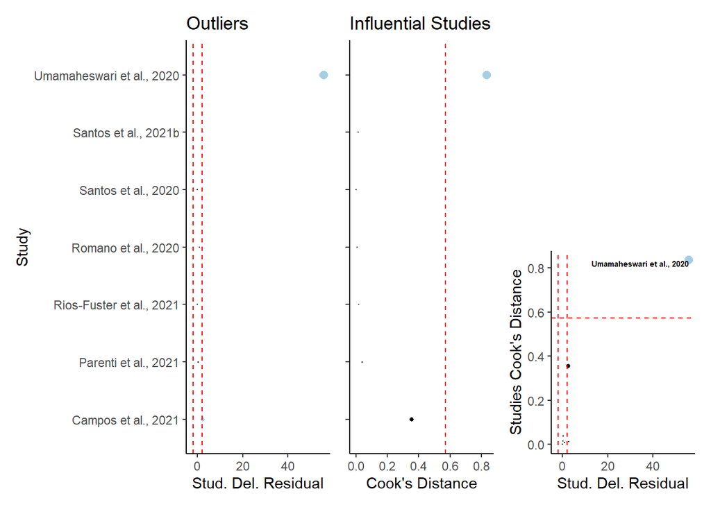

```r
influentialcases_plots(mRE, "ML_RobVar", "ML", 3)
```

# Multilevel meta-regression

SYRCLE PROTOCOL: Meta-regression will be used for outcomes with at least 10 experiments.

> The minimal number of studies or effect sizes required by a multilevel meta-regression remains unknown, albeit some simulation studies suggest that the estimates of model coefficients of a multilevel meta-regression are generally stable under various simulated situations.(Yang et al. 2023) … the complexity of parameterization of such a meta-regression requires a large dataset to make optimization algorithms free of convergence issues.(Yang et al. 2023)

## Model 1: Size, Duration, Development

```r
df_MR <- select(df, c("Year", "StudyID", "Study", "EScluster", "ESid", "DevelopmentalStage",
    "ExposureDurationDays", "ParticleSizeMean", "yi", "vi"))

mname1 <- "Base"
mname2 <- paste0(mname1, "_RobVar")

# are there differences between the different forms of DevelopmentalStage?
# mods_formula <- formula(~ ParticleSizeMean +
# ExposureDurationDays*DevelopmentalStage) at least one of the
# DevelopmentalStage levels is different than zero?
mods_formula <- formula(~0 + ParticleSizeMean + ExposureDurationDays * DevelopmentalStage)

mMR[[mname1]] <- rma.mv(yi, VCV, random = RE_formula, mods = mods_formula, data = df_MR,
    slab = Study, method = "REML", test = "t", dfs = "contain", level = 95)  #it will only keep complete cases

nSt_MR <- mMR[[mname1]]$s.nlevels[1]  # number of studies
nEC_MR <- mMR[[mname1]]$s.nlevels[2]  # number of ESclusters
nES_MR <- mMR[[mname1]]$s.nlevels[3]  # number of independent ES

print(paste0("Number of studies: ", nSt_MR, ", number of ES clusters: ", nEC_MR,
    " and number of independent observations of ES: ", nES_MR))
```

```
[1] "Number of studies: 6, number of ES clusters: 13 and number of independent observations of ES: 20"
```

```r
mMR[[mname2]] <- robust(mMR[[mname1]], cluster = df_MR$Study, clubSandwich = TRUE,
    verbose = TRUE)
```

```
Error in Wald_testing(C_mat = constraints, beta = beta, vcov = vcov, test = test,  :
  Variance-covariance matrix of the contrast is not positive definite. The test cannot be computed.
```

```r
mMR[[mname2]][["i2"]] <- i2_ml(mMR[[mname2]])
mMR[[mname2]][["icc"]] <- round(mMR[[mname2]]$sigma2/sum(mMR[[mname2]]$sigma2), 3)

anova(mMR[[mname2]], btt = c("DevelopmentalStage", "ExposureDurationDays", "ParticleSizeMean"))
```

```
                  spec coefs   Fval df1   df2   pval
1   DevelopmentalStage   3:6 0.0000   4 -0.67     NA
2 ExposureDurationDays   2,6 2.9646   2  0.56 0.5036
3     ParticleSizeMean     1 0.1172   1  1.77 0.7684
```

The meta-regression comprised 20 comparisons from 13 control group clusters of 6 independent studies.

#### Diagnostics plots

```
Multivariate Meta-Analysis Model (k = 20; method: REML)

  logLik  Deviance       AIC       BIC      AICc
-28.4698   56.9396   74.9396   80.6911  119.9396

Variance Components:

            estim    sqrt  nlvls  fixed                factor
sigma^2.1  0.0000  0.0001      6     no                 Study
sigma^2.2  0.0000  0.0000     13     no       Study/EScluster
sigma^2.3  0.7611  0.8724     20     no  Study/EScluster/ESid

Test for Residual Heterogeneity:
QE(df = 14) = 29.9640, p-val = 0.0077

Number of estimates:   20
Number of clusters:    6
Estimates per cluster: 0-10 (mean: 0.34, median: 0)

Model Results:

                                              estimate      se¹     tval¹
ParticleSizeMean                               -0.0044  0.0127   -0.3423
ExposureDurationDays                            0.1729  0.0440    3.9339
DevelopmentalStageLarva                        -0.5683  1.1566   -0.4914
DevelopmentalStageJuvenile                     -1.8764  3.9295   -0.4775
DevelopmentalStageAdult                         1.1551  0.3923    2.9447
ExposureDurationDays:DevelopmentalStageLarva    0.0233  0.1973    0.1183
                                                df¹    pval¹     ci.lb¹
ParticleSizeMean                              1.77   0.7684    -0.0666
ExposureDurationDays                             1   0.1585    -0.3856
DevelopmentalStageLarva                       1.05   0.7061   -13.7028
DevelopmentalStageJuvenile                    1.89   0.6825   -19.7740
DevelopmentalStageAdult                          1   0.2084    -3.8289
ExposureDurationDays:DevelopmentalStageLarva  1.18   0.9226    -1.7254
                                                ci.ub¹
ParticleSizeMean                               0.0578
ExposureDurationDays                           0.7314
DevelopmentalStageLarva                       12.5661
DevelopmentalStageJuvenile                    16.0212
DevelopmentalStageAdult                        6.1391
ExposureDurationDays:DevelopmentalStageLarva   1.7721

---
Signif. codes:  0 '***' 0.001 '**' 0.01 '*' 0.05 '.' 0.1 ' ' 1

1) results based on cluster-robust inference (var-cov estimator: CR2,
   approx t/F-tests and confidence intervals, df: Satterthwaite approx)
```

|  | ML | REML |
| --- | --- | --- |
| ll | -36.41421 | -28.46978 |
| dev | 31.25593 | 56.93955 |
| AIC | 90.82843 | 74.93955 |
| BIC | 99.79002 | 80.69107 |
| AICc | 108.82843 | 119.93955 |

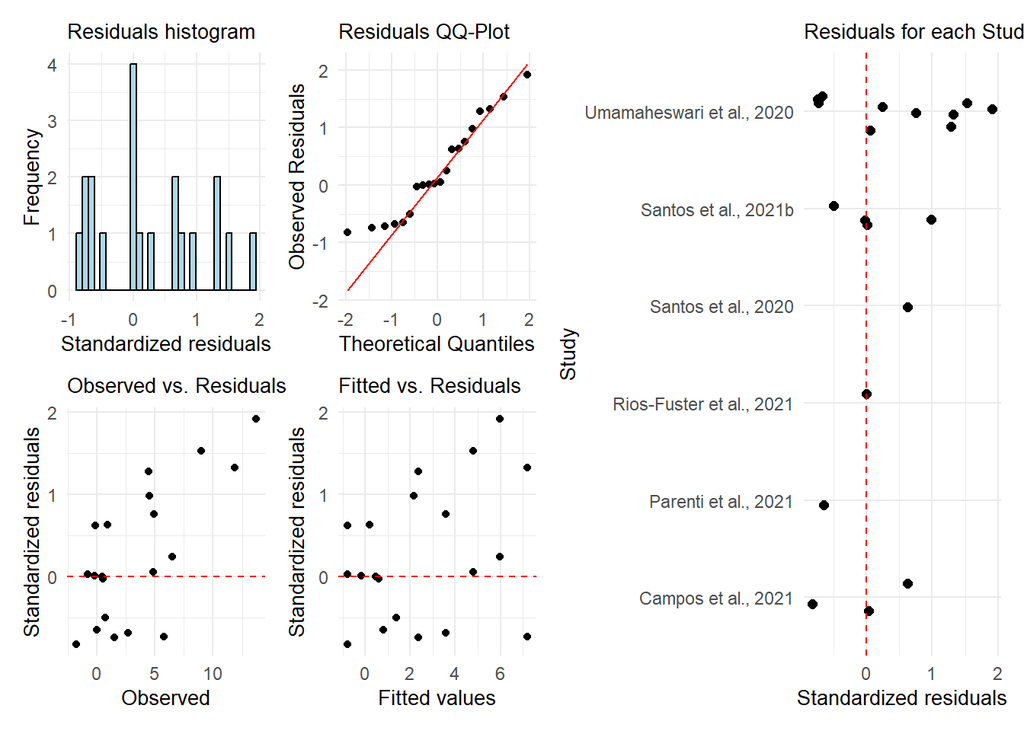

#### Influential cases

#### Orchard plots

(Nakagawa et al. 2021)

## Model 2: + Concentration

```r
df_MR <- select(df, c("Year", "StudyID", "Study", "EScluster", "ESid", "DevelopmentalStage",
    "ExposureDurationDays", "ParticleSizeMean", "Concentration_mg_L", "yi", "vi"))

mname1 <- "Conc+"
mname2 <- paste0(mname1, "_RobVar")

mods_formula <- formula(~0 + ParticleSizeMean + Concentration_mg_L + ExposureDurationDays *
    DevelopmentalStage)

mMR[[mname1]] <- rma.mv(yi, VCV, random = RE_formula, mods = mods_formula, data = df_MR,
    slab = Study, method = "REML", test = "t", dfs = "contain", level = 95)  #it will only keep complete cases

nSt_MR <- mMR[[mname1]]$s.nlevels[1]  # number of studies
nEC_MR <- mMR[[mname1]]$s.nlevels[2]  # number of ESclusters
nES_MR <- mMR[[mname1]]$s.nlevels[3]  # number of independent ES

print(paste0("Number of studies: ", nSt_MR, ", number of ES clusters: ", nEC_MR,
    " and number of independent observations of ES: ", nES_MR))
```

```
[1] "Number of studies: 5, number of ES clusters: 12 and number of independent observations of ES: 19"
```

```r
mMR[[mname2]] <- robust(mMR[[mname1]], cluster = df_MR$Study, clubSandwich = TRUE,
    verbose = TRUE)
```

```
Error in Wald_testing(C_mat = constraints, beta = beta, vcov = vcov, test = test,  :
  Variance-covariance matrix of the contrast is not positive definite. The test cannot be computed.
```

```r
mMR[[mname2]][["i2"]] <- i2_ml(mMR[[mname2]])
mMR[[mname2]][["icc"]] <- round(mMR[[mname2]]$sigma2/sum(mMR[[mname2]]$sigma2), 3)

anova(mMR[[mname2]], btt = c("DevelopmentalStage", "ExposureDurationDays", "ParticleSizeMean",
    "Concentration_mg_L"))
```

```
                  spec coefs   Fval df1   df2   pval
1   DevelopmentalStage   4:6 0.0000   3 -0.08     NA
2 ExposureDurationDays   3,6 2.8903   2  0.56 0.5068
3     ParticleSizeMean     1 0.0070   1  1.96 0.9410
4   Concentration_mg_L     2 0.2017   1  1.01 0.7306
```

The meta-regression comprised 19 comparisons from 12 control group clusters of 5 independent studies.

#### Diagnostics plots

```
Multivariate Meta-Analysis Model (k = 19; method: REML)

  logLik  Deviance       AIC       BIC      AICc
-27.1067   54.2134   72.2134   77.2979  132.2134

Variance Components:

            estim    sqrt  nlvls  fixed                factor
sigma^2.1  0.0000  0.0001      5     no                 Study
sigma^2.2  0.0000  0.0000     12     no       Study/EScluster
sigma^2.3  0.7747  0.8801     19     no  Study/EScluster/ESid

Test for Residual Heterogeneity:
QE(df = 13) = 26.2966, p-val = 0.0155

Number of estimates:   19
Number of clusters:    5
Estimates per cluster: 0-10 (mean: 0.32, median: 0)

Model Results:

                                              estimate      se¹     tval¹
ParticleSizeMean                               -0.0026  0.0305   -0.0838
Concentration_mg_L                             -0.1184  0.2637   -0.4491
ExposureDurationDays                            0.1728  0.0442    3.9080
DevelopmentalStageLarva                        -0.3606  1.3057   -0.2762
DevelopmentalStageAdult                         1.1654  0.3877    3.0057
ExposureDurationDays:DevelopmentalStageLarva    0.0208  0.2166    0.0958
                                                df¹    pval¹     ci.lb¹
ParticleSizeMean                              1.96   0.9410    -0.1364
Concentration_mg_L                            1.01   0.7306    -3.3846
ExposureDurationDays                             1   0.1595    -0.3891
DevelopmentalStageLarva                       1.14   0.8241   -12.9432
DevelopmentalStageAdult                          1   0.2044    -3.7592
ExposureDurationDays:DevelopmentalStageLarva  1.18   0.9373    -1.9013
                                                ci.ub¹
ParticleSizeMean                               0.1313
Concentration_mg_L                             3.1477
ExposureDurationDays                           0.7348
DevelopmentalStageLarva                       12.2220
DevelopmentalStageAdult                        6.0899
ExposureDurationDays:DevelopmentalStageLarva   1.9428

---
Signif. codes:  0 '***' 0.001 '**' 0.01 '*' 0.05 '.' 0.1 ' ' 1

1) results based on cluster-robust inference (var-cov estimator: CR2,
   approx t/F-tests and confidence intervals, df: Satterthwaite approx)
```

|  | ML | REML |
| --- | --- | --- |
| ll | -35.14105 | -27.10668 |
| dev | 28.78488 | 54.21337 |
| AIC | 88.28210 | 72.21337 |
| BIC | 96.78205 | 77.29791 |
| AICc | 108.28210 | 132.21337 |

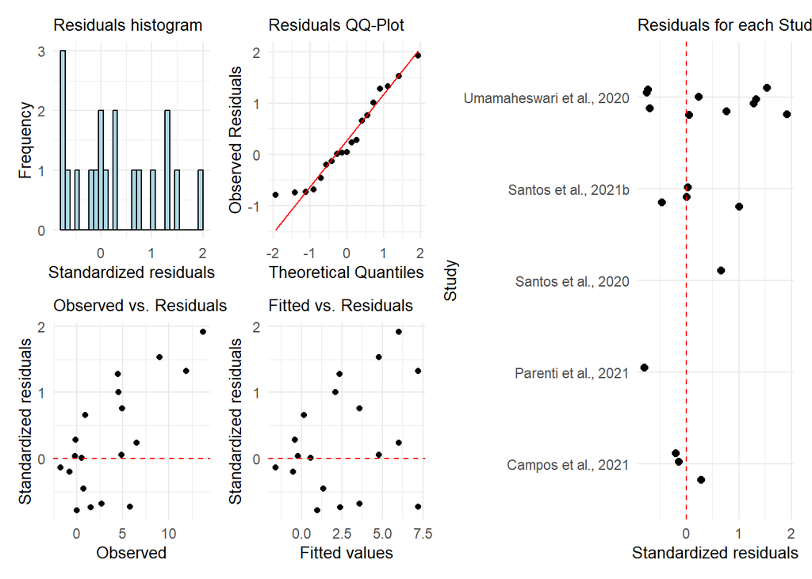

#### Influential cases

#### Orchard plots

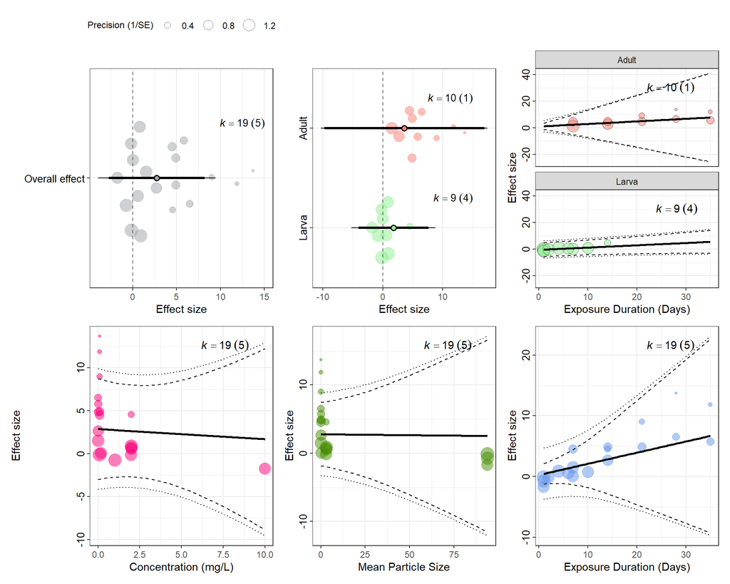

## Model 3: + ParticleMaterial

```r
df_MR <- select(df, c("Year", "StudyID", "Study", "EScluster", "ESid", "DevelopmentalStage",
    "ExposureDurationDays", "ParticleSizeMean", "ParticleMaterial", "yi", "vi"))

mname1 <- "PartMat+"
mname2 <- paste0(mname1, "_RobVar")

mods_formula <- formula(~(ParticleSizeMean + ExposureDurationDays * DevelopmentalStage +
    ParticleMaterial))

mMR[[mname1]] <- rma.mv(yi, VCV, random = RE_formula, mods = mods_formula, data = df_MR,
    slab = Study, method = "REML", test = "t", dfs = "contain", level = 95)  #it will only keep complete cases

nSt_MR <- mMR[[mname1]]$s.nlevels[1]  # number of studies
nEC_MR <- mMR[[mname1]]$s.nlevels[2]  # number of ESclusters
nES_MR <- mMR[[mname1]]$s.nlevels[3]  # number of independent ES

print(paste0("Number of studies: ", nSt_MR, ", number of ES clusters: ", nEC_MR,
    " and number of independent observations of ES: ", nES_MR))
```

```
[1] "Number of studies: 6, number of ES clusters: 13 and number of independent observations of ES: 20"
```

```r
mMR[[mname2]] <- robust(mMR[[mname1]], cluster = df_MR$Study, clubSandwich = TRUE,
    verbose = TRUE)
```

```
Error in Wald_testing(C_mat = constraints, beta = beta, vcov = vcov, test = test,  :
  Variance-covariance matrix of the contrast is not positive definite. The test cannot be computed.
```

```r
mMR[[mname2]][["i2"]] <- i2_ml(mMR[[mname2]])
mMR[[mname2]][["icc"]] <- round(mMR[[mname2]]$sigma2/sum(mMR[[mname2]]$sigma2), 3)

anova(mMR[[mname2]], btt = c("DevelopmentalStage", "ExposureDurationDays", "ParticleSizeMean",
    "ParticleMaterial"))
```

```
                  spec coefs    Fval df1   df2   pval
1   DevelopmentalStage 4:5,7  0.0000   3 -0.32     NA
2 ExposureDurationDays   3,7  3.3927   2  0.63 0.4608
3     ParticleSizeMean     2 42.9331   1  1.11 0.0800 .
4     ParticleMaterial     6 38.7918   1  1.10 0.0865 .
```

The meta-regression comprised 20 comparisons from 13 control group clusters of 6 independent studies.

#### Diagnostics plots

```
Multivariate Meta-Analysis Model (k = 20; method: REML)

  logLik  Deviance       AIC       BIC      AICc
-27.0696   54.1392   74.1392   79.7887  184.1392

Variance Components:

            estim    sqrt  nlvls  fixed                factor
sigma^2.1  0.0000  0.0001      6     no                 Study
sigma^2.2  0.0000  0.0000     13     no       Study/EScluster
sigma^2.3  0.9053  0.9515     20     no  Study/EScluster/ESid

Test for Residual Heterogeneity:
QE(df = 13) = 29.0026, p-val = 0.0065

Number of estimates:   20
Number of clusters:    6
Estimates per cluster: 0-10 (mean: 0.34, median: 0)

Model Results:

                                              estimate       se¹     tval¹
intrcpt                                         1.1678   0.3185    3.6669
ParticleSizeMean                                0.3924   0.0599    6.5523
ExposureDurationDays                            0.1732   0.0465    3.7252
DevelopmentalStageLarva                        -2.8603   0.8460   -3.3809
DevelopmentalStageJuvenile                    -85.8701  12.2710   -6.9978
ParticleMaterialLDPE                          -36.2124   5.8142   -6.2283
ExposureDurationDays:DevelopmentalStageLarva    0.0444   0.1220    0.3639
                                                df¹    pval¹      ci.lb¹
intrcpt                                          1   0.1691     -2.8596
ParticleSizeMean                              1.11   0.0800     -0.2097
ExposureDurationDays                             1   0.1670     -0.4176
DevelopmentalStageLarva                       2.17   0.0690     -6.2373
DevelopmentalStageJuvenile                    1.11   0.0742   -208.6978
ParticleMaterialLDPE                           1.1   0.0865    -96.2455
ExposureDurationDays:DevelopmentalStageLarva  1.44   0.7623     -0.7367
                                                ci.ub¹
intrcpt                                        5.1953
ParticleSizeMean                               0.9946   .
ExposureDurationDays                           0.7641
DevelopmentalStageLarva                        0.5166   .
DevelopmentalStageJuvenile                    36.9576   .
ParticleMaterialLDPE                          23.8208   .
ExposureDurationDays:DevelopmentalStageLarva   0.8255

---
Signif. codes:  0 '***' 0.001 '**' 0.01 '*' 0.05 '.' 0.1 ' ' 1

1) results based on cluster-robust inference (var-cov estimator: CR2,
   approx t/F-tests and confidence intervals, df: Satterthwaite approx)
```

|  | ML | REML |
| --- | --- | --- |
| ll | -36.42637 | -27.06960 |
| dev | 31.28023 | 54.13921 |
| AIC | 92.85273 | 74.13921 |
| BIC | 102.81006 | 79.78870 |
| AICc | 117.29718 | 184.13921 |

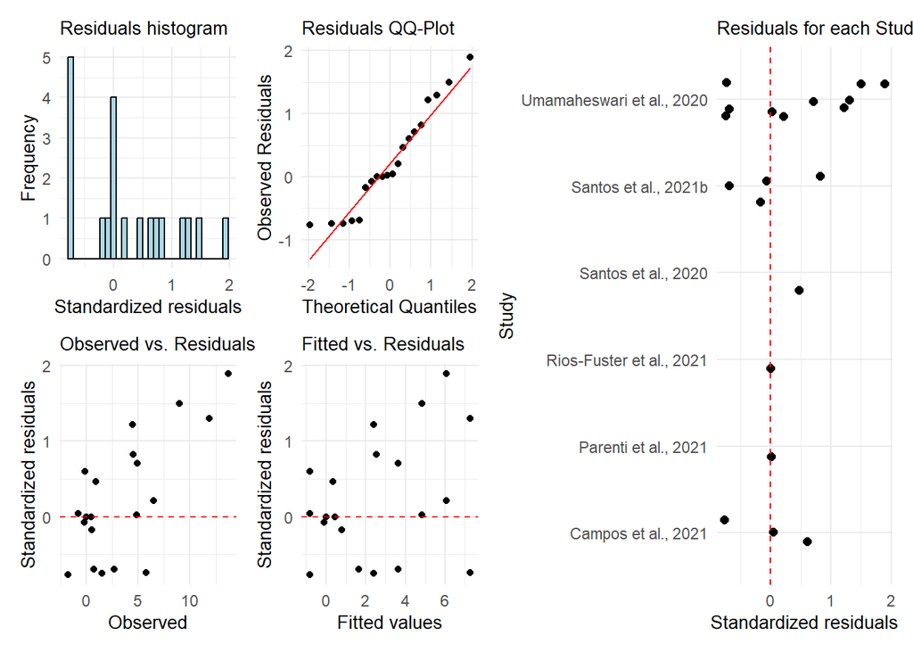

#### Influential cases

#### Orchard plots

# Referências

Harrer, Mathias, Pim Cuijpers, Toshi A. Furukawa, and David D. Ebert. n.d. *Chapter 9 Publication Bias | Doing Meta-Analysis in R*. https://bookdown.org/MathiasHarrer/Doing_Meta_Analysis_in_R/pub-bias.html.

Nakagawa, Shinichi, Malgorzata Lagisz, Michael D. Jennions, Julia Koricheva, Daniel W. A. Noble, Timothy H. Parker, Alfredo Sánchez-Tójar, Yefeng Yang, and Rose E. O’Dea. 2022. “Methods for Testing Publication Bias in Ecological and Evolutionary Meta-Analyses.” *Methods in Ecology and Evolution* 13 (1): 4–21. https://doi.org/10.1111/2041-210X.13724.

Nakagawa, Shinichi, Malgorzata Lagisz, Rose E. O’Dea, Joanna Rutkowska, Yefeng Yang, Daniel W. A. Noble, and Alistair M. Senior. 2021. “The Orchard Plot: Cultivating a Forest Plot for Use in Ecology, Evolution, and Beyond.” *Research Synthesis Methods* 12 (1): 4–12. https://doi.org/10.1002/jrsm.1424.

Stanley, T. D. 2017. “Limitations of PET-PEESE and Other Meta-Analysis Methods.” *Social Psychological and Personality Science* 8 (5): 581–91. https://doi.org/10.1177/1948550617693062.

Viechtbauer, Wolfgang. 2010. “Conducting Meta-Analyses in R with the Metafor Package.” *Journal of Statistical Software* 36 (August): 1–48. https://doi.org/10.18637/jss.v036.i03.

———. 2022. “Konstantopoulos (2011) [the Metafor Package].” https://www.metafor-project.org/doku.php/analyses:konstantopoulos2011.

Viechtbauer, Wolfgang, and Mike W.-L. Cheung. 2010. “Outlier and Influence Diagnostics for Meta-Analysis.” *Research Synthesis Methods* 1 (2): 112–25. https://doi.org/10.1002/jrsm.11.

Yang, Yefeng, Malcolm Macleod, Jinming Pan, Malgorzata Lagisz, and Shinichi Nakagawa. 2023. “Advanced Methods and Implementations for the Meta-Analyses of Animal Models: Current Practices and Future Recommendations.” *Neuroscience & Biobehavioral Reviews* 146 (March): 105016. https://doi.org/10.1016/j.neubiorev.2022.105016.